# 土地銀行數位種子人才發展計劃

> 資料視覺化與分析結果表達

[郭耀仁](https://hahow.in/@tonykuoyj) | yaojenkuo@ntu.edu.tw

## 目錄

- 資料視覺化基本原則- Tableau 視覺化操作與互動式圖表（P.3）
- Power BI 管理與分析報表建置（P.54）
- 個案討論：以 gapminder 資料實作動態氣泡圖、以中選會選舉資料庫實作動態長條圖（P.56）
- 以 Python 資料視覺化工具重現 Tableau/Power BI 的作品（P.58）
- 實作：檢視各小組題目中資料視覺化的需求，盤點資料來源、需求欄位，以 mock data 測試能否順利完成（P.80）

## 資料視覺化基本原則 - Tableau 視覺化操作與互動式圖表

## 資料視覺化的兩個經典案例

1. Hans Rosling's 200 Countries, 200 Years, 4 Minutes: https://youtu.be/jbkSRLYSojo?si=5WkjOoiU_IPuKGsR
2. Charles Minard's Napoleon's disastrous Russian campaign of 1812: https://en.wikipedia.org/wiki/Charles_Joseph_Minard

## 兩個案例之所以為經典

- 在短篇幅中涵蓋豐富資訊，但是精準傳達想表達的核心理念。
- 資料是多維度，呈現形式是二維的。
- 美觀。

## 資料科學管線：Visualise

- 視覺化的基礎：資料類型映射為 Aesthetics
- Aesthetics 的維度：
  - 軸。
  - 形狀。
  - 顏色。
  - 大小、粗細。
  - 其他。

[figure not shown]

來源：https://r4ds.had.co.nz/introduction.html

## 如何復刻 Hans Rosling's 200 Countries, 200 Years, 4 Minutes

- 資料需求。
  - X 軸：人均 GDP
  - Y 軸：預期壽命。
  - 顏色：洲別。
  - 大小：人口數。
  - 時間軸：年份。
- 視覺化需求。
  - 概念驗證：`matplotlib`
  - 成品：`plotly.express`

## 來自 [gapminder.org](https://www.gapminder.org/data/) 的資料

- [gapminder.org](https://www.gapminder.org/data/) 基金會是由 Hans Rosling 與其家人共同創立的基金會，目的是透過統計資料的使用和理解，促進以事實為基礎的世界觀察。
- [gapminder.org](https://www.gapminder.org/data/) 提供不同來源與格式的世界統計資料：
  - Systema Globalis
  - [Fast Track](https://github.com/open-numbers/ddf--gapminder--fasttrack)
  - World Development Indicators

## 練習採用 [Fast Track](https://github.com/open-numbers/ddf--gapminder--fasttrack) 資料

- X 軸：人均 GDP https://github.com/open-numbers/ddf--gapminder--fasttrack/blob/master/countries_etc_datapoints/ddf--datapoints--gdp_pcap--by--country--time.csv
- Y 軸：預期壽命。https://github.com/open-numbers/ddf--gapminder--fasttrack/blob/master/countries_etc_datapoints/ddf--datapoints--lex--by--country--time.csv
- 顏色：洲別。https://github.com/open-numbers/ddf--gapminder--fasttrack/blob/master/ddf--entities--geo--country.csv
- 大小：人口數。https://github.com/open-numbers/ddf--gapminder--fasttrack/blob/master/countries_etc_datapoints/ddf--datapoints--pop--by--country--time.csv
- 時間軸：年份。

## 為什麼資料需要視覺化

視覺化在探索性資料分析中佔有舉足輕重的地位，因為對人來說原始資料是相當抽象的。

## 抽象的原始資料

例如我們透過 `np.random` 建立的隨機 `ndarray`

```python
import numpy as np
import matplotlib.pyplot as plt

m = 10000
uniform_ndarray = np.random.random(m)
normal_ndarray = np.random.normal(0, 1, m)
randint_ndarray = np.random.randint(1, 7, size=m)
print(uniform_ndarray)
print(normal_ndarray)
print(randint_ndarray)
```

```
[0.54150204 0.98920713 0.02354435 ... 0.82199828 0.26658615 0.76236914]
[-1.02485509  0.94645349 -0.62650276 ... -1.17918446  0.37318572
 -0.59398374]
[6 5 2 ... 4 2 3]
```

## 將原始資料視覺化

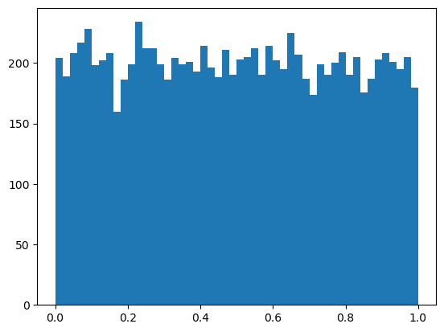

```python
show_uniform_ndarray(uniform_ndarray)
```

## 將原始資料視覺化（續）

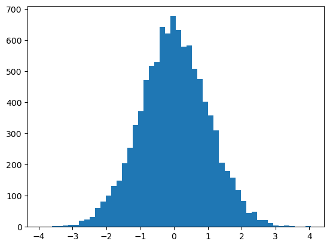

```python
show_normal_ndarray(normal_ndarray)
```

## 將原始資料視覺化（續）

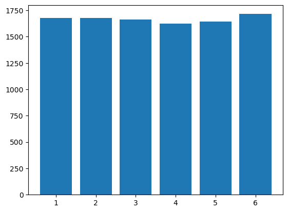

```python
show_randint_ndarray(randint_ndarray)
```

## 什麼是 Matplotlib

> Matplotlib 是 Python 資料視覺化的第三方模組。

來源：https://matplotlib.org

## （沒什麼用的冷知識）Matplotlib 與 Matlab 有一點關係

- Matrix plotting library.
- 模仿 Matlab 作圖的指令與功能。

來源：https://matplotlib.org/stable/users/project/history.html

## 根據說明文件的範例載入

實際上主要在使用的是 `matplotlib.pyplot`

來源：https://matplotlib.org/stable/tutorials/introductory/usage.html#sphx-glr-tutorials-introductory-usage-py

```python
import matplotlib.pyplot as plt
```

## 新手學習 Matplotlib 的最大挑戰：兩種不同的作圖語法

1. Matlab 風格。
2. 物件導向風格。

## Matlab 風格

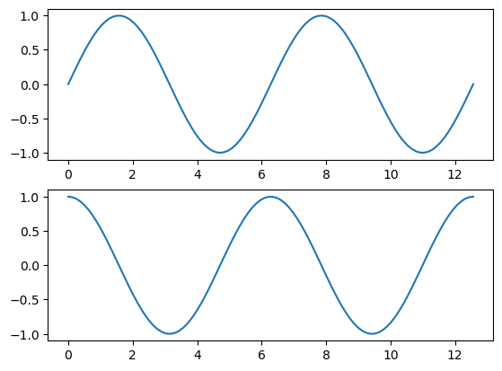

```python
x = np.linspace(0, np.pi*4, 100)
plt.figure()
plt.subplot(2, 1, 1)
plt.plot(x, np.sin(x))
plt.subplot(2, 1, 2)
plt.plot(x, np.cos(x))
plt.show()
```

## Matlab 風格的優缺點

- 優點：指令式語法，比較直觀。
- 缺點：狀態型介面，需要依程式碼順序閱讀才能理解。

## 物件導向風格

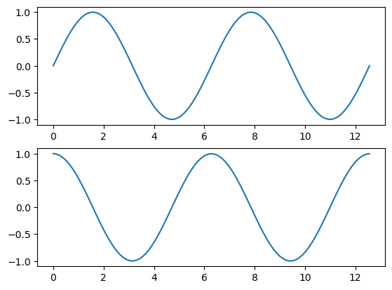

```python
fig, axes = plt.subplots(2, 1)
axes[0].plot(x, np.sin(x))
axes[1].plot(x, np.cos(x))
plt.show()
```

## 物件導向風格的優缺點

- 優點：物件型介面，不需要依程式碼順序閱讀也能理解。
- 缺點：對不熟悉物件導向概念的人不友善。

弱勢對物件導向概念已經有入門理解採用物件導向風格是最適合的。

## 視覺化的標準五步驟

1. 建立 `ndarray`
2. 建立「畫布物件」與「軸物件」。
3. 使用「軸物件」的作圖方法建立主要圖形。
4. 使用「軸物件」的作圖方法添加圖形元素。
5. 顯示或者儲存圖形。

## 建立 `ndarray`

```python
x = np.linspace(0, np.pi*2, 100)
sinx = np.sin(x)
```

## 建立「畫布物件」與「軸物件」

使用 `plt.subplots()` 函數。

```
<class 'matplotlib.figure.Figure'>
<class 'matplotlib.axes._subplots.AxesSubplot'>
```

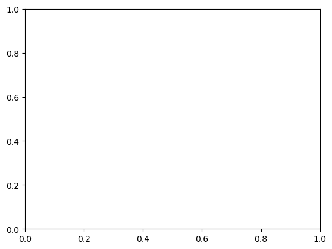

```python
fig, ax = plt.subplots()
print(type(fig))
print(type(ax))
```

## 使用「軸物件」的作圖方法建立主要圖形

`AxesSubplot.plot()` 能夠建立線圖。

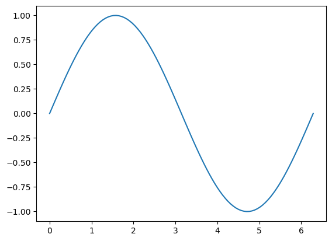

```python
fig = plt.figure()
ax = plt.axes()
ax.plot(x, sinx)
```

## 使用「軸物件」的作圖方法添加圖形元素

```
(-5.0, 5.0)
```

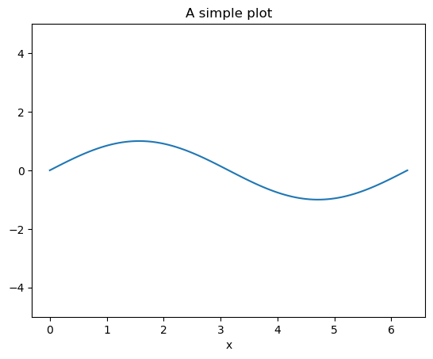

```python
fig = plt.figure()
ax = plt.axes()
ax.plot(x, sinx)
ax.set_title('A simple plot')
ax.set_xlabel('x')
ax.set_ylim(-5, 5)
```

## 顯示圖形

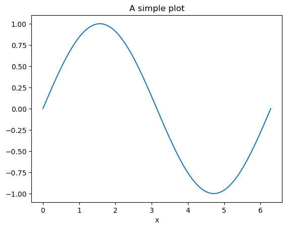

```python
fig = plt.figure()
ax = plt.axes()
ax.plot(x, sinx)
ax.set_title('A simple plot')
ax.set_xlabel('x')
plt.show()
```

## 儲存圖形：可支援的圖片格式

```python
fig = plt.figure()
fig.canvas.get_supported_filetypes()
```

```
{'eps': 'Encapsulated Postscript',
 'jpg': 'Joint Photographic Experts Group',
 'jpeg': 'Joint Photographic Experts Group',
 'pdf': 'Portable Document Format',
 'pgf': 'PGF code for LaTeX',
 'png': 'Portable Network Graphics',
 'ps': 'Postscript',
 'raw': 'Raw RGBA bitmap',
 'rgba': 'Raw RGBA bitmap',
 'svg': 'Scalable Vector Graphics',
 'svgz': 'Scalable Vector Graphics',
 'tif': 'Tagged Image File Format',
 'tiff': 'Tagged Image File Format',
 'webp': 'WebP Image Format'}
```

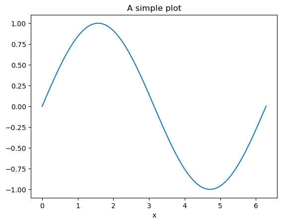

```python
fig = plt.figure()
axes = plt.axes()
axes.plot(x, sinx)
axes.set_title('A simple plot')
axes.set_xlabel('x')
fig.savefig('a_simple_plot.png')
```

## 如何調整中文字型無法顯示的問題

Matplotlib 預設使用的字體不支援中文、日文、韓文等非歐美語系文字。

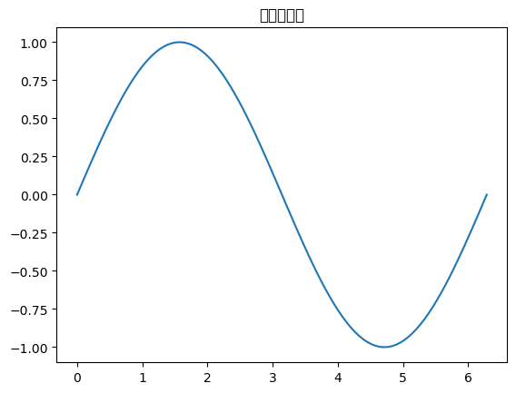

```python
fig = plt.figure()
ax = plt.axes()
ax.plot(x, sinx)
ax.set_title('簡單的圖形')
plt.show()
```

## 指定可以支援中文字體的字型

使用 `matplotlib.font_manager` 的 `FontProperties()` 函數。

```python
from matplotlib.font_manager import FontProperties

stheiti = FontProperties(fname="STHeiti Medium.ttc") # Font supports traditional Chinese
```

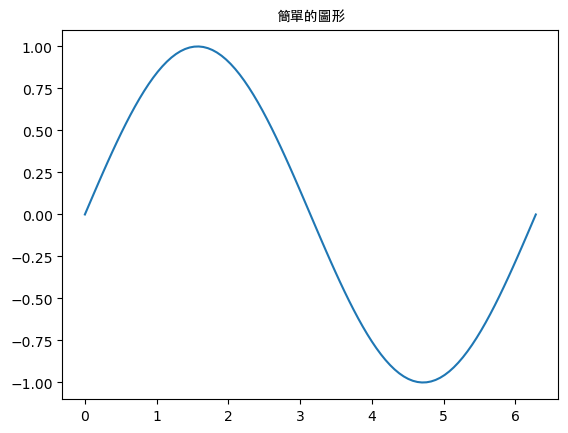

```python
fig = plt.figure()
ax = plt.axes()
ax.plot(x, sinx)
ax.set_title('簡單的圖形', fontproperties=stheiti)
plt.show()
```

## 軸物件不同的方法對應不同的主要圖形

- `AxesSubplot.hist()` 觀察分配的直方圖。
- `AxesSubplot.scatter()` 觀察相關的散佈圖。
- `AxesSubplot.plot()` 觀察趨勢的線圖。
- `AxesSubplot.barh()` 觀察排序的長條圖。
- ...等。

## 觀察分配的直方圖

`AxesSubplot.hist()` 輸入一個數值 `ndarray`

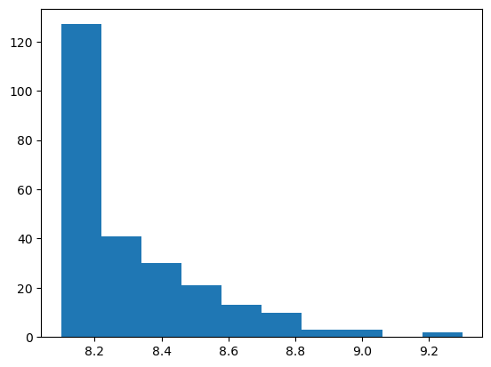

```python
import pandas as pd

csv_url = "https://raw.githubusercontent.com/datainpoint/classroom-landbank-2026/refs/heads/main/data/movies.csv"
movies = pd.read_csv(csv_url)
ratings = movies["rating"].values
fig, ax = plt.subplots()
ax.hist(ratings)
plt.show()
```

## 觀察相關的散佈圖

`AxesSubplot.scatter()` 輸入兩個數值 `ndarray`

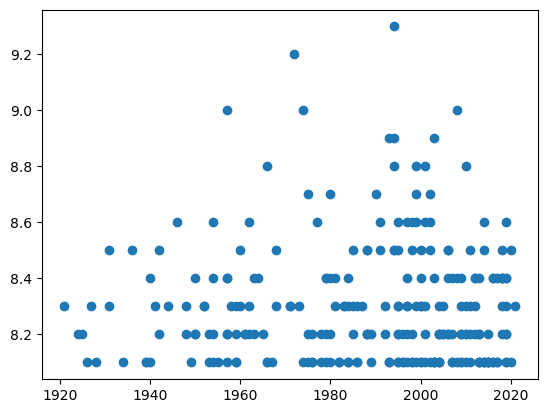

```python
release_years = movies["release_year"].values
ratings = movies["rating"].values
fig, ax = plt.subplots()
ax.scatter(release_years, ratings)
plt.show()
```

## 觀察趨勢的線圖

`AxesSubplot.plot()` 輸入一個日期時間、一個數值 `ndarray`

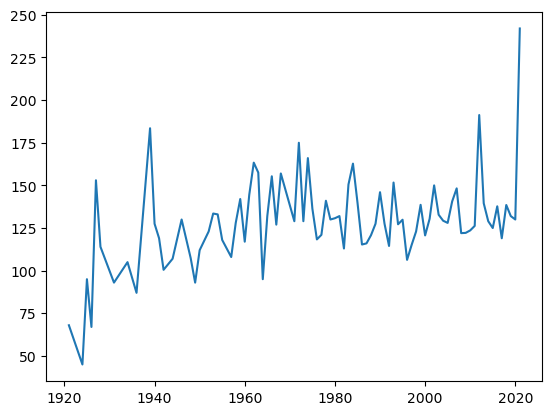

```python
runtime_by_years = movies.groupby("release_year")["runtime"].mean()
distinct_years = runtime_by_years.index
mean_runtimes = runtime_by_years.values
fig, ax = plt.subplots()
ax.plot(distinct_years, mean_runtimes)
plt.show()
```

## 觀察排序的長條圖

`AxesSubplot.barh()` 輸入一個文字序列、一個數值 `ndarray`

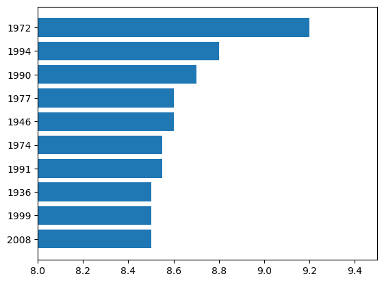

```python
rating_by_years = movies.groupby("release_year")["rating"].mean().sort_values()
top_ten_rating_by_years = rating_by_years[-10:]
distinct_years = top_ten_rating_by_years.index.astype(str)
mean_ratings = top_ten_rating_by_years.values
fig = plt.figure()
ax = plt.axes()
ax.barh(distinct_years, mean_ratings)
ax.set_xlim(8, 9.5)
plt.show()
```

## 常用的圖形元素

- 添加標題與軸標籤。
- 調整軸刻度。
- 調整軸刻度標籤。
- 調整軸的上下限。
- 添加文字。
- 添加圖例。

## 如何添加標題與軸標籤

- 使用 `AxesSubplot.set_title()` 添加標題。
- 使用 `AxesSubplot.set_xlabel()` 添加 x 軸標籤。
- 使用 `AxesSubplot.set_ylabel()` 添加 y 軸標籤。

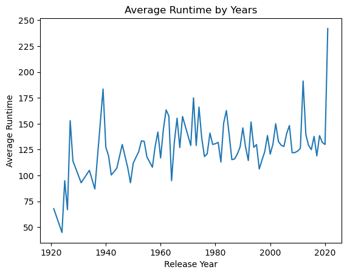

```python
runtime_by_years = movies.groupby("release_year")["runtime"].mean()
distinct_years = runtime_by_years.index
mean_runtimes = runtime_by_years.values
fig, ax = plt.subplots()
ax.plot(distinct_years, mean_runtimes)
ax.set_title("Average Runtime by Years") # title
ax.set_xlabel("Release Year")            # x-axis label
ax.set_ylabel("Average Runtime")         # y-axis label
plt.show()
```

## 如何調整軸刻度

- 使用 `AxesSubplot.set_xticks()` 調整 x 軸刻度。
- 使用 `AxesSubplot.set_yticks()` 調整 y 軸刻度。

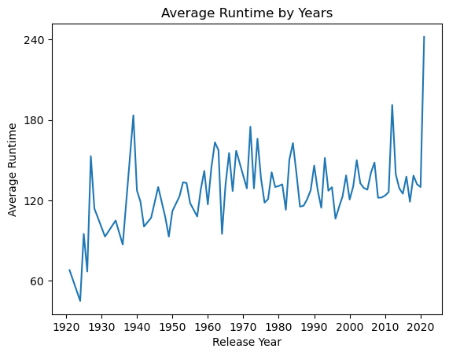

```python
fig, ax = plt.subplots()
ax.plot(distinct_years, mean_runtimes)
ax.set_title("Average Runtime by Years")
ax.set_xlabel("Release Year")
ax.set_ylabel("Average Runtime")
ax.set_xticks(range(1920, 2030, 10)) # narrow ticks
ax.set_yticks([60, 120, 180, 240])   # specify ticks
plt.show()
```

## 如何調整軸刻度標籤

- 使用 `AxesSubplot.set_xticklabels()` 調整 x 軸刻度標籤。
- 使用 `AxesSubplot.set_yticklabels()` 調整 y 軸刻度標籤。

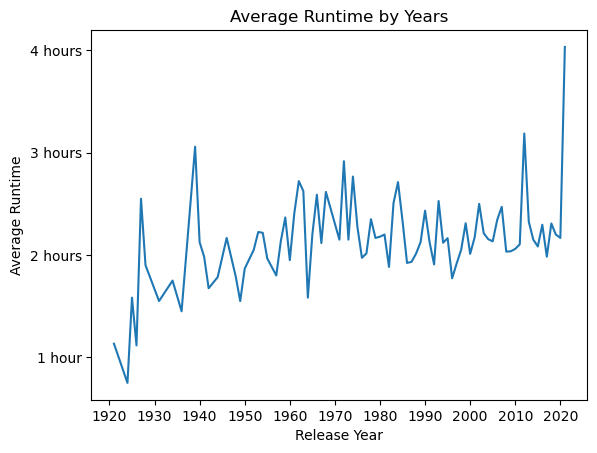

```python
fig, ax = plt.subplots()
ax.plot(distinct_years, mean_runtimes)
ax.set_title("Average Runtime by Years")
ax.set_xlabel("Release Year")
ax.set_ylabel("Average Runtime")
ax.set_xticks(range(1920, 2030, 10))
ax.set_yticks([60, 120, 180, 240])
ax.set_yticklabels(["1 hour", "2 hours", "3 hours", "4 hours"]) # specify ticklabels
plt.show()
```

## 如何調整軸的上下限

- 使用 `AxesSubplot.set_xlim()` 調整 x 軸的上下限。
- 使用 `AxesSubplot.set_ylim()` 調整 y 軸的上下限。

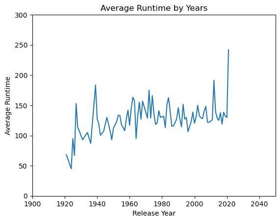

```python
fig, ax = plt.subplots()
ax.plot(distinct_years, mean_runtimes)
ax.set_title("Average Runtime by Years")
ax.set_xlabel("Release Year")
ax.set_ylabel("Average Runtime")
ax.set_xlim(1900, 2050) # set x-limits
ax.set_ylim(0, 300)     # set y-limits
plt.show()
```

## 如何添加文字

使用 `AxesSubplot.text(x, y, 'Some Strings')` 在 `(x, y)` 的位置添加 `'Some Strings'`

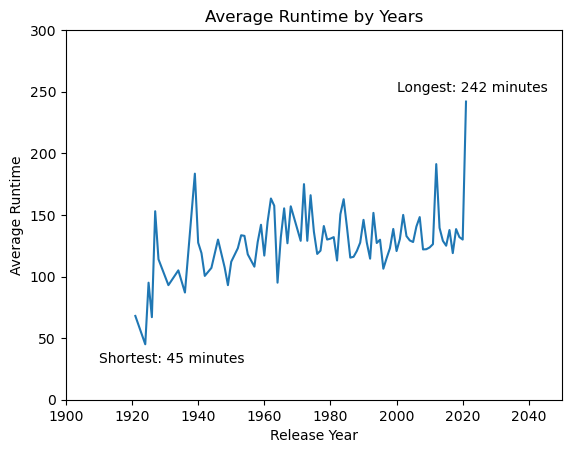

```python
fig, ax = plt.subplots()
ax.plot(distinct_years, mean_runtimes)
ax.set_title("Average Runtime by Years")
ax.set_xlabel("Release Year")
ax.set_ylabel("Average Runtime")
ax.set_xlim(1900, 2050) # set x-limits
ax.set_ylim(0, 300)     # set y-limits
ax.text(1910, 30, f"Shortest: {mean_runtimes.min():.0f} minutes") # add text at (1910, 30)
ax.text(2000, 250, f"Longest: {mean_runtimes.max():.0f} minutes") # add text at (2000, 250)
plt.show()
```

## 如何添加圖例

- 使用 `Figure.legend()` 並在主要圖形加上 `label` 參數。
- 因為 `runtime` 與 `rating` 的量尺不同，使用 `AxesSubplot.twinx()` 製作雙軸（Dual-axis）

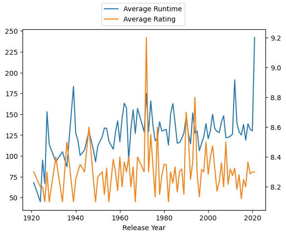

```python
runtime_by_years = movies.groupby("release_year")["runtime"].mean()
rating_by_years = movies.groupby("release_year")["rating"].mean()
distinct_years = runtime_by_years.index
mean_runtimes = runtime_by_years.values
mean_ratings = rating_by_years.values
fig, ax1 = plt.subplots()
ax1.plot(distinct_years, mean_runtimes, color="tab:blue", label="Average Runtime")
ax1.set_xlabel("Release Year")
ax2 = ax1.twinx()
ax2.plot(distinct_years, mean_ratings, color="tab:orange", label="Average Rating")
fig.legend(loc="upper center")
plt.show()
```

## 什麼是子圖

子圖（Subplots）指的是在一個畫布物件上有多個軸物件的組成結構，多個軸物件就稱為子圖。

## 如何在一個畫布上建立子圖

使用 `plt.subplots()` 時採預設，輸出是一個 `Figure` 類別以及一個 `AxesSubplot` 類別。

```
<class 'matplotlib.figure.Figure'>
<class 'matplotlib.axes._subplots.AxesSubplot'>
```

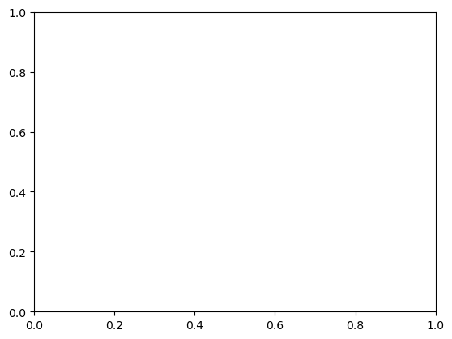

```python
fig, ax = plt.subplots() # no inputs
print(type(fig))
print(type(ax))
```

## 如何在一個畫布上建立子圖（續）

使用 `plt.subplots()` 時輸入 `m, n`，輸出變為一個 `Figure` 類別以及一個外型為 `(m, n)` 的 `ndarray` 類別。

```
<class 'matplotlib.figure.Figure'>
<class 'numpy.ndarray'>
```

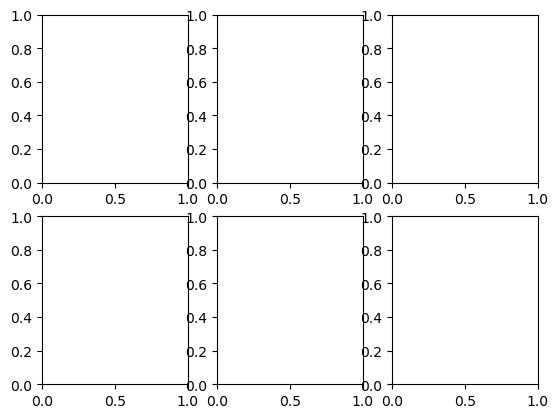

```python
fig, axes = plt.subplots(2, 3)
print(type(fig))
print(type(axes))
```

## 可以使用作圖方法、添加圖形元素的軸物件到哪了呢

- 在 `ndarray` 中有 $m \times n$ 個軸物件。
- 以 `ndarray[row, column]` 就能取得位於 `(row, column)` 的軸物件。

```
(2, 3)
<class 'matplotlib.axes._subplots.AxesSubplot'>
<class 'matplotlib.axes._subplots.AxesSubplot'>
<class 'matplotlib.axes._subplots.AxesSubplot'>
<class 'matplotlib.axes._subplots.AxesSubplot'>
<class 'matplotlib.axes._subplots.AxesSubplot'>
<class 'matplotlib.axes._subplots.AxesSubplot'>
```

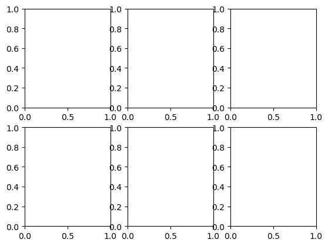

```python
m = 2
n = 3
fig, axes = plt.subplots(m, n)
print(axes.shape)
for row in range(m):
    for column in range(n):
        print(type(axes[row, column]))
```

```
(2,)
```

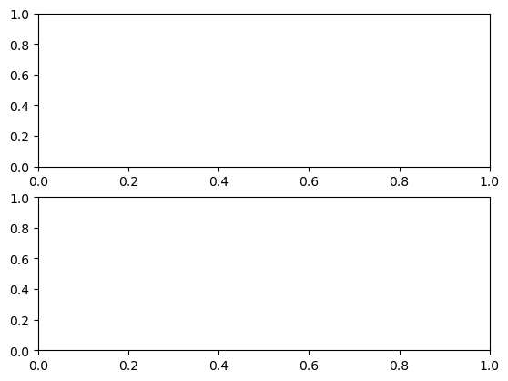

```python
fig, axes = plt.subplots(2, 1)
axes.shape
```

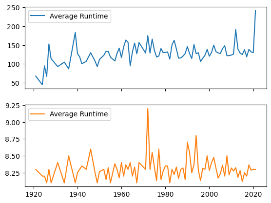

```python
fig, axes = plt.subplots(2, 1, sharex=True)
axes[0].plot(distinct_years, mean_runtimes, color="tab:blue", label="Average Runtime")
axes[0].legend(loc="upper left")
axes[1].plot(distinct_years, mean_ratings, color="tab:orange", label="Average Runtime")
axes[1].legend(loc="upper left")
plt.show()
```

## Tableau 可以直接匯入整理好的單一資料

實作資料：https://raw.githubusercontent.com/datainpoint/classroom-landbank-2026/refs/heads/main/data/gapminder_plotting.csv

## Power BI 管理與分析報表建置

## Power BI 可以直接匯入整理好的單一資料

實作資料：https://raw.githubusercontent.com/datainpoint/classroom-landbank-2026/refs/heads/main/data/gapminder_plotting.csv

## 個案討論：以 gapminder 資料實作動態氣泡圖、以中選會選舉資料庫實作動態長條圖

## 實作資料

- gapminder 資料：https://raw.githubusercontent.com/datainpoint/classroom-landbank-2026/refs/heads/main/data/gapminder.db
- 中選會選舉資料庫：https://raw.githubusercontent.com/datainpoint/classroom-landbank-2026/refs/heads/main/data/taiwan_election_2024.db

來源：[gapminder.org](https://www.gapminder.org/data/), [中選會選舉資料庫](https://db.cec.gov.tw/ElecTable/Election?type=President)

## 以 Python 資料視覺化工具重現 Tableau/Power BI 的作品

## 以 `pandas` 載入 [Fast Track](https://github.com/open-numbers/ddf--gapminder--fasttrack) 資料

```python
file_names = ["ddf--datapoints--gdp_pcap--by--country--time",
              "ddf--datapoints--lex--by--country--time",
              "ddf--datapoints--pop--by--country--time",
              "ddf--entities--geo--country"]
table_names = ["gdp_per_capita", "life_expectancy", "population", "geography"]
```

```python
import pandas as pd

df_dict = dict()
for file_name, table_name in zip(file_names, table_names):
    file_path = f"data/{file_name}.csv"
    df = pd.read_csv(file_path)
    df_dict[table_name] = df
```

## 以 `sqlite3` 與 `pandas` 建立資料庫 `gapminder.db`

來源：https://pandas.pydata.org/docs/reference/api/pandas.DataFrame.to_sql.html

```python
import sqlite3

connection = sqlite3.connect("data/gapminder.db")
for k, v in df_dict.items():
    v.to_sql(name=k, con=connection, index=False, if_exists="replace")
connection.close()
```

## 在 `gapminder.db` 建立一個檢視表 `plotting`

```python
drop_view_sql = """
DROP VIEW IF EXISTS plotting;
"""
```

```python
create_view_sql = """
CREATE VIEW plotting AS
SELECT geography.name AS country_name,
       gdp_per_capita.time AS dt_year,
       gdp_per_capita.gdp_pcap AS gdp_per_capita,
       geography.world_4region AS continent,
       life_expectancy.lex AS life_expectancy,
       population.pop AS population
  FROM gdp_per_capita
  JOIN geography
    ON gdp_per_capita.country = geography.country
  JOIN life_expectancy
    ON gdp_per_capita.country = life_expectancy.country AND
       gdp_per_capita.time = life_expectancy.time
  JOIN population
    ON gdp_per_capita.country = population.country AND
       gdp_per_capita.time = population.time
 WHERE gdp_per_capita.time < 2024;
"""
```

```python
cur = connection.cursor()
cur.execute(drop_view_sql)
cur.execute(create_view_sql)
connection.close()
```

## 整理程式碼為一個類別 `CreateGapminderDB`

```python
class CreateGapminderDB:
    def __init__(self):
        self.file_names = ["ddf--datapoints--gdp_pcap--by--country--time",
                           "ddf--datapoints--lex--by--country--time",
                           "ddf--datapoints--pop--by--country--time",
                           "ddf--entities--geo--country"]
        self.table_names = ["gdp_per_capita", "life_expectancy", "population", "geography"]
    def import_as_dataframe(self):
        df_dict = dict()
        for file_name, table_name in zip(self.file_names, self.table_names):
            file_path = f"data/{file_name}.csv"
            df = pd.read_csv(file_path)
            df_dict[table_name] = df
        return df_dict
```

```python
    def create_database(self):
        connection = sqlite3.connect("data/gapminder.db")
        df_dict = self.import_as_dataframe()
        for k, v in df_dict.items():
            v.to_sql(name=k, con=connection, index=False, if_exists="replace")
        drop_view_sql = """
        DROP VIEW IF EXISTS plotting;
        """
        create_view_sql = """
        CREATE VIEW plotting AS
        SELECT geography.name AS country_name,
               geography.world_4region AS continent,
               gdp_per_capita.time AS dt_year,
               gdp_per_capita.gdp_pcap AS gdp_per_capita,
               life_expectancy.lex AS life_expectancy,
               population.pop AS population
          FROM gdp_per_capita
          JOIN geography
            ON gdp_per_capita.country = geography.country
          JOIN life_expectancy
            ON gdp_per_capita.country = life_expectancy.country AND
               gdp_per_capita.time = life_expectancy.time
          JOIN population
            ON gdp_per_capita.country = population.country AND
               gdp_per_capita.time = population.time
         WHERE gdp_per_capita.time < 2024;
        """
        cur = connection.cursor()
        cur.execute(drop_view_sql)
        cur.execute(create_view_sql)
        connection.close()
```

## 檢查類別 `CreateGapminderDB` 能否順利運行

```python
create_gapminder_db = CreateGapminderDB()
create_gapminder_db.create_database()
```

## 完成後用 SQLiteStudio 檢視一下

## 從 `plotting` 檢視表選取所有的資料

```python
connection = sqlite3.connect("data/gapminder.db")
plotting_df = pd.read_sql("""SELECT * FROM plotting;""", con=connection)
connection.close()
```

## 透過 `matplotlib` 模組繪製靜態圖

```python
year_to_plot = 1800 # year_to_plot = 2023
subset_df = plotting_df[plotting_df["dt_year"] == year_to_plot]
lex = subset_df["life_expectancy"].values
gdp_pcap = subset_df["gdp_per_capita"].values
cont = subset_df["continent"].values
color_map = {
    "asia": "r",
    "africa": "g",
    "europe": "b",
    "americas": "c"
}
```

```python
import matplotlib.pyplot as plt

fig, ax = plt.subplots()
for xi, yi, ci in zip(gdp_pcap, lex, cont):
    ax.scatter(xi, yi, color=color_map[ci])
ax.set_title(f"The world in {year_to_plot}")
ax.set_xlabel("GDP Per Capita(in USD)")
ax.set_ylabel("Life Expectancy")
ax.set_ylim(20, 100)
ax.set_xlim(0, 100000)
plt.show()
```

## 透過 `matplotlib` 模組繪製動畫

```python
fig, ax = plt.subplots()
def update_plot(year_to_plot: int):
    ax.clear()
    subset_df = plotting_df[plotting_df["dt_year"] == year_to_plot]
    lex = subset_df["life_expectancy"].values
    gdp_pcap = subset_df["gdp_per_capita"].values
    cont = subset_df["continent"].values
    color_map = {
        "asia": "r",
        "africa": "g",
        "europe": "b",
        "americas": "c"
    }
    for xi, yi, ci in zip(gdp_pcap, lex, cont):
        ax.scatter(xi, yi, color=color_map[ci])
    ax.set_title(f"The world in {year_to_plot}")
    ax.set_xlabel("GDP Per Capita(in USD)")
    ax.set_ylabel("Life Expectancy")
    ax.set_ylim(20, 100)
    ax.set_xlim(0, 100000)
```

## 透過 `matplotlib` 模組繪製動畫（續）

- `fig`: 畫布物件。
- `func`: 更新軸物件的函數。
- `frames`: 要傳入 `func` 的數列。
- `interval`: 動畫間隔，以毫秒為單位。
- `fps`: 動畫每秒幀數。

來源：https://matplotlib.org/stable/users/explain/animations/animations.html

```python
import matplotlib.animation as animation

ani = animation.FuncAnimation(fig, func=update_plot, frames=range(2000, 2024), interval=10)
ani.save("animation.gif", fps=10)
```

## 從 `plotting` 檢視表選取所有的資料

```python
connection = sqlite3.connect("data/gapminder.db")
plotting_df = pd.read_sql("""SELECT * FROM plotting;""", con=connection)
connection.close()
```

## 透過 `plotly.express` 模組繪製動畫

- `animation_frame`: 動畫所仰賴的時間軸變數。
- `hover_name`: 滑鼠移到資料點上所顯示的名稱。
- `log_x`: X 軸是否要使用對數刻度（log scale）。

來源：https://plotly.com/python-api-reference/generated/plotly.express.scatter.html

```python
import plotly.express as px

fig = px.scatter(plotting_df, x="gdp_per_capita", y="life_expectancy",
                 animation_frame="dt_year", animation_group="country_name",
                 size="population", color="continent", hover_name="country_name",
                 size_max=100, range_x=[500, 100000], range_y=[20, 90], log_x=True,
                 title="Gapminder Clone 1800-2023")
fig.write_html("gapminder_clone.html", auto_open=True)
```

## 亮點

- 有別於坊間範例所使用 gapminder 資料集（精簡版僅涵蓋 1952-2007，五年為時間間隔），這個專案從 [gapminder.org](https://www.gapminder.org/data/) 取得詳細資料集。
- 建立了檢視表關聯多個原始資料集。
- 以 `matplotlib` 進行概念驗證。
- 以 `plotly.express` 做出成品。
- 成品能夠以 GitHub Page 網址直接訪問。
- 可以重現（Reproducible）。

## 延伸優化：技術面

- 在成品中加入洲別或國家的篩選 UI，例如下拉式選單（Dropdown）或複選框（Checkbox）。
- 考量使用情境，決定資料庫的建立與成品的生成是否需要整合在一個程式碼中。
- 除了 GitHub Page 以外，考量其他部署選項。

## 延伸優化：商業分析應用面

- 資料點的大小並不是溝通的核心，在 XY 座標軸的移動趨勢才是溝通核心。
- 若僅有一個連續型數值變數、一個時間軸變數，用線圖就綽綽有餘。
- 有兩個連續型數值變數、一個時間軸變數就可以應用這個練習專案。

## 延伸優化：商業分析應用面（續）

- 可以運用 X 軸、Y 軸變數合適的數值（例如平均數、中位數）劃設分水嶺，在 XY 座標軸上建立四個象限。
- 例如商業分析廣受眾人愛戴的 BCG growth share matrix，X 軸、Y 軸分別為產品或服務的市占率、成長率，其中有四個象限。
- 在特定時間段，觀察資料點是往「低市占、低成長」的 Pet 移動、往「低市占、高成長」的 Question mark 移動、往「高市占、高成長」的 Star 移動抑或是往「高市占、低成長」的 Cash cow 移動。

來源：https://www.bcg.com/about/overview/our-history/growth-share-matrix

## 實作：檢視各小組題目中資料視覺化的需求，盤點資料來源、需求欄位，以 mock data 測試能否順利完成